# Black Friday: EDA, Spending Prediction and Recommendation System

[Kelly Raas](https://github.com/kellyraas), [Hendrik Mischo](https://github.com/hendrik-mischo)

21 January 2019

The objectives of this project are the following:  
1. Discover the underlying patterns of the data and derive insights about customers and products, which are useful to the marketing team and management.  
2. Create a model to predict how much a given customer will likely spend.  
3. Build a [Recommendation system](https://en.wikipedia.org/wiki/Recommender_system) that recommends new products to customers, which they are likely to purchase.

To achieve the goal #1 we will perform an Exploratory Data Analysis (EDA) using the Tidyverse library for data wrangling and visualizations.

Given that goal #2 can be an extensive project by itself, we will only scratch the surface here. However, we will establish the baseline performance of a regression model and a tree-based model and provide suggestions on how the performance could be further improved.

Goal #3 is going to be achieved by with the [Collaborative Filtering (CF)](https://en.wikipedia.org/wiki/Collaborative_filtering) technique. We will use the Recommenderlab library and compare Item Based Collaborative Filtering (IBCF) and User Based Collaborative Filtering (UBCF) to find the optimal method.

Use the links below to jump to the respective section.

- Data Cleaning
- Exploratory Data Analysis
  - Customer Analysis
  - Product Analysis
- Predicting Customer Spending
- Recommendation System

# 1 Data Cleaning

Let’s start by importing the relevant libraries and the data.

```r
library(tidyverse)      # For data wrangling and visualization
library(gridExtra)      # To arrage plots
library(scales)         # For different scales e.g. US-dollars
library(recommenderlab) # For Collaborative Filtering
library(caret)          # For Linear Regression
library(randomForest)   # For Random Forests
library(ggthemes)       # For themes

# Import the data
data = read.csv("blackfriday.csv")
attach(data)

# Define the theme to be applied to the plots
theme.hc = function(){
  theme(
    text                = element_text(size = 12),
    title               = element_text(hjust = 0),
    axis.title.x        = element_text(hjust = .5),
    axis.title.y        = element_text(hjust = .5),
    panel.grid.major.y  = element_line(color = 'gray', size = .15),
    panel.grid.minor.y  = element_blank(),
    panel.grid.major.x  = element_blank(),
    panel.grid.minor.x  = element_blank(),
    panel.border        = element_blank(),
    panel.background    = element_blank(),
    legend.position     = "right",
    legend.title        = element_blank())}
```

Now let’s have a look at the data.

```r
head(data)
```

```
  User_ID Product_ID Gender   Age Occupation City_Category
1 1000001  P00069042      F  0-17         10             A
2 1000001  P00248942      F  0-17         10             A
3 1000001  P00087842      F  0-17         10             A
4 1000001  P00085442      F  0-17         10             A
5 1000002  P00285442      M   55+         16             C
6 1000003  P00193542      M 26-35         15             A
  Stay_In_Current_City_Years Marital_Status Product_Category_1
1                          2              0                  3
2                          2              0                  1
3                          2              0                 12
4                          2              0                 12
5                         4+              0                  8
6                          3              0                  1
  Product_Category_2 Product_Category_3 Purchase
1                 NA                 NA     8370
2                  6                 14    15200
3                 NA                 NA     1422
4                 14                 NA     1057
5                 NA                 NA     7969
6                  2                 NA    15227
```

Check how the values are distributed and if there are any abnormal values.

```r
summary(data)
```

```
    User_ID            Product_ID     Gender        Age
 Min.   :1000001   P00265242:  1858   F:132197   0-17 : 14707
 1st Qu.:1001495   P00110742:  1591   M:405380   18-25: 97634
 Median :1003031   P00025442:  1586              26-35:214690
 Mean   :1002992   P00112142:  1539              36-45:107499
 3rd Qu.:1004417   P00057642:  1430              46-50: 44526
 Max.   :1006040   P00184942:  1424              51-55: 37618
                   (Other)  :528149              55+  : 20903
   Occupation     City_Category Stay_In_Current_City_Years
 Min.   : 0.000   A:144638      0 : 72725
 1st Qu.: 2.000   B:226493      1 :189192
 Median : 7.000   C:166446      2 : 99459
 Mean   : 8.083                 3 : 93312
 3rd Qu.:14.000                 4+: 82889
 Max.   :20.000

 Marital_Status   Product_Category_1 Product_Category_2 Product_Category_3
 Min.   :0.0000   Min.   : 1.000     Min.   : 2.00      Min.   : 3.0
 1st Qu.:0.0000   1st Qu.: 1.000     1st Qu.: 5.00      1st Qu.: 9.0
 Median :0.0000   Median : 5.000     Median : 9.00      Median :14.0
 Mean   :0.4088   Mean   : 5.296     Mean   : 9.84      Mean   :12.7
 3rd Qu.:1.0000   3rd Qu.: 8.000     3rd Qu.:15.00      3rd Qu.:16.0
 Max.   :1.0000   Max.   :18.000     Max.   :18.00      Max.   :18.0
                                     NA's   :166986     NA's   :373299
    Purchase
 Min.   :  185
 1st Qu.: 5866
 Median : 8062
 Mean   : 9334
 3rd Qu.:12073
 Max.   :23961
```

Check the variable types.

```r
glimpse(data)
```

```
Observations: 537,577
Variables: 12
$ User_ID                    <int> 1000001, 1000001, 1000001, 1000001,...
$ Product_ID                 <fct> P00069042, P00248942, P00087842, P0...
$ Gender                     <fct> F, F, F, F, M, M, M, M, M, M, M, M,...
$ Age                        <fct> 0-17, 0-17, 0-17, 0-17, 55+, 26-35,...
$ Occupation                 <int> 10, 10, 10, 10, 16, 15, 7, 7, 7, 20...
$ City_Category              <fct> A, A, A, A, C, A, B, B, B, A, A, A,...
$ Stay_In_Current_City_Years <fct> 2, 2, 2, 2, 4+, 3, 2, 2, 2, 1, 1, 1...
$ Marital_Status             <int> 0, 0, 0, 0, 0, 0, 1, 1, 1, 1, 1, 1,...
$ Product_Category_1         <int> 3, 1, 12, 12, 8, 1, 1, 1, 1, 8, 5, ...
$ Product_Category_2         <int> NA, 6, NA, 14, NA, 2, 8, 15, 16, NA...
$ Product_Category_3         <int> NA, 14, NA, NA, NA, NA, 17, NA, NA,...
$ Purchase                   <int> 8370, 15200, 1422, 1057, 7969, 1522...
```

See if there are any NAs.

```r
sapply(data, function(x) sum(is.na(x)))
```

```
                   User_ID                 Product_ID
                         0                          0
                    Gender                        Age
                         0                          0
                Occupation              City_Category
                         0                          0
Stay_In_Current_City_Years             Marital_Status
                         0                          0
        Product_Category_1         Product_Category_2
                         0                     166986
        Product_Category_3                   Purchase
                    373299                          0
```

We notice the following issues:  
1) Some numeric variables should be factors.  
2) `User_ID` and `Product_ID` should be characters.  
3) There are quite a lot of NAs in `Product_Category_2` and `Product_Category_3`.  
4) `Purchase` seems to be formatted in cents given the high values.  
Next we will clean the data. The missing product categories will be represented as category 0. `Purchase` will be converted to dollars.

```r
data = data %>%
  mutate(
    # Convert several variables to character
    User_ID = as.character(User_ID),
    Product_ID = as.character(Product_ID),
    # Convert several variables to factors
    Occupation = as.factor(Occupation),
    Marital_Status = as.factor(Marital_Status),
    Product_Category_1 = as.factor(Product_Category_1),
    Product_Category_2 = as.factor(Product_Category_2),
    Product_Category_3 = as.factor(Product_Category_3),
    # Missing product categories will be represented as category 0
    Product_Category_2 = ifelse(is.na(Product_Category_2), 0, Product_Category_2),
    Product_Category_3 = ifelse(is.na(Product_Category_3), 0, Product_Category_3),
    # Convert cents to dollars
    Purchase = as.numeric(Purchase)/100
    )
attach(data)
```

Let’s have a look at the clean data.

```r
head(data)
```

```
  User_ID Product_ID Gender   Age Occupation City_Category
1 1000001  P00069042      F  0-17         10             A
2 1000001  P00248942      F  0-17         10             A
3 1000001  P00087842      F  0-17         10             A
4 1000001  P00085442      F  0-17         10             A
5 1000002  P00285442      M   55+         16             C
6 1000003  P00193542      M 26-35         15             A
  Stay_In_Current_City_Years Marital_Status Product_Category_1
1                          2              0                  3
2                          2              0                  1
3                          2              0                 12
4                          2              0                 12
5                         4+              0                  8
6                          3              0                  1
  Product_Category_2 Product_Category_3 Purchase
1                  0                  0    83.70
2                  5                 11   152.00
3                  0                  0    14.22
4                 13                  0    10.57
5                  0                  0    79.69
6                  1                  0   152.27
```

# 2 Exploratory Data Analysis

This section is divided into two parts. We will first analyze the customers and then the products.

## 2.1 Customer Analysis

What can we find out about our customers?

### 2.1.1 How many unique customers are there?

```r
data %>% distinct(User_ID) %>% nrow()
```

```
[1] 5891
```

### 2.1.2 Gender Distribution

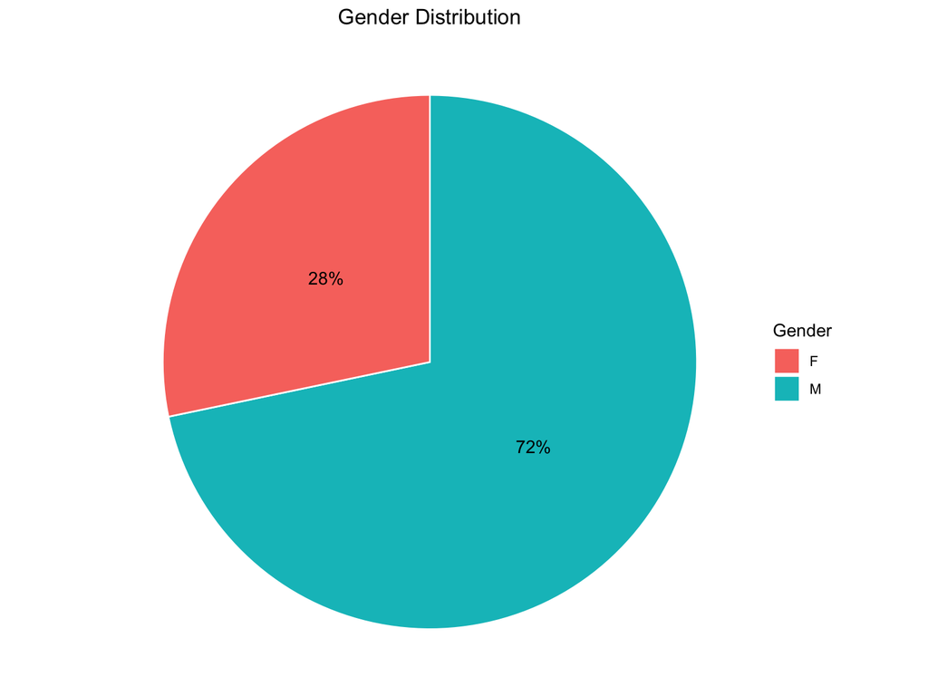

```r
data %>%
  group_by(Gender) %>%
  summarise(total = n_distinct(User_ID)) %>%
  mutate(share = total/sum(total)) %>%
  ggplot(aes(x = "", y = total, fill = Gender)) +
  geom_bar(width = 1, stat = "identity", color = "white") +
  coord_polar("y", start=0) +
  geom_text(aes(label = paste0(round(share*100), "%")), position = position_stack(vjust = 0.5)) +
  labs(title = "Gender Distribution") +
  theme_void() +
    theme(plot.title = element_text(hjust = 0.5)) +
    theme(legend.position="right")
```

Men are significantly more respresented than women in this dataset.

### 2.1.3 Age Distribution

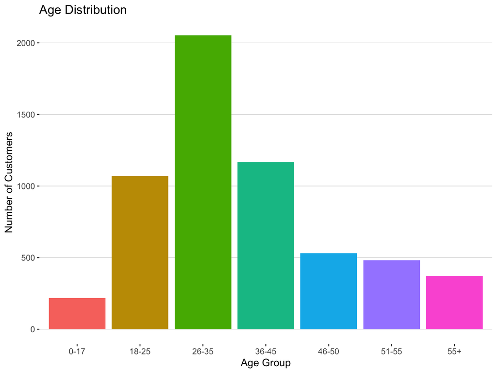

```r
data %>%
  group_by(Age) %>%
  summarize(n.customers = n_distinct(User_ID)) %>%
  ggplot(aes(x = Age, y = n.customers, fill = Age)) +
  geom_histogram(stat = "identity") +
  ggtitle("Age Distribution") +
  xlab("Age Group") +
  ylab("Number of Customers") +
  guides(fill = FALSE) +
  theme.hc()
```

The majority of customers is of age between 18 and 45.